# Subgraphing Batch Cases

Eric Bridgeford

December 15, 2017

# Case 1: Session Partitioning

- Within a study with TRT, partition into 2 sets of sessions, the first session and second session
- Is there a batch effect between sessions of a particular study?

## Procedure

- Take first half of sessions from all connectomes as set 1, other half as set 2.
  - Ie, if 4 sessions in a dataset, we would choose 2 sessions randomly, and then the other
1. Train model on first group of sessions, and test on second half to obtain $\hat{L}_1$, and train model on second half, and test on second group of sessions to obtain $\hat{L}_2$.
2. Train model on both sets at once, and obtain $\tau_{observed}$
3. permute the set labels of the combined set $nperm$ times (maintaining sex of each graph) to obtain the distribution of $\tau_{null}$, reporting $\hat{p}$, the estimator of $\mathbb{E}\left[\frac{\tau_{null} < \tau_{observed}}{nperm}\right]$

### DWI

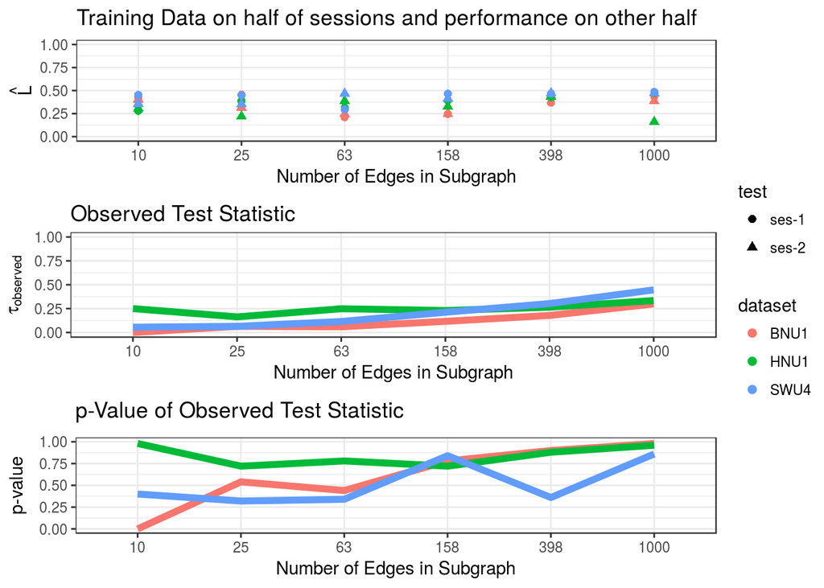

```r
result <- readRDS('/data/paper/subgraphing_results/case1dwi.rds')
data <- prepare_case1(result)
plot_case1(data)
```

### fMRI

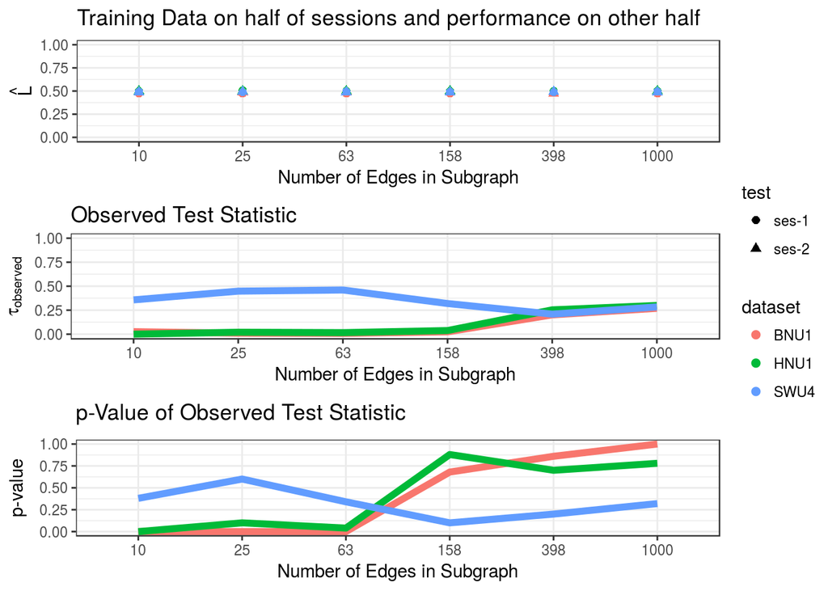

```r
result <- readRDS('/data/paper/subgraphing_results/case1fmri.rds')
data <- prepare_case1(result)
plot_case1(data)
```

# Case 2: Subject Partitioning

- Within a study, partition into 2 sets of subjects, the first half of subjects and second half of subjects
- Is there a batch effect between subjects in a particular study?

## Procedure

- Take first half of subjects from all connectomes as set 1, other half as set 2.
  - Ie, if 50 subjects in a dataset, we would choose 25 subjects randomly, and then the other
1. Train model on first group of subjects, and test on second half to obtain $\hat{L}_1$, and train model on second half, and test on second group of subjects to obtain $\hat{L}_2$.
2. Train model on both sets at once, and obtain $\tau_{observed}$
3. permute the set labels of the combined set $nperm$ times (maintaining sex of each graph) to obtain the distribution of $\tau_{null}$, reporting $\hat{p}$, the estimator of $\mathbb{E}\left[\frac{\tau_{null} < \tau_{observed}}{nperm}\right]$

### DWI

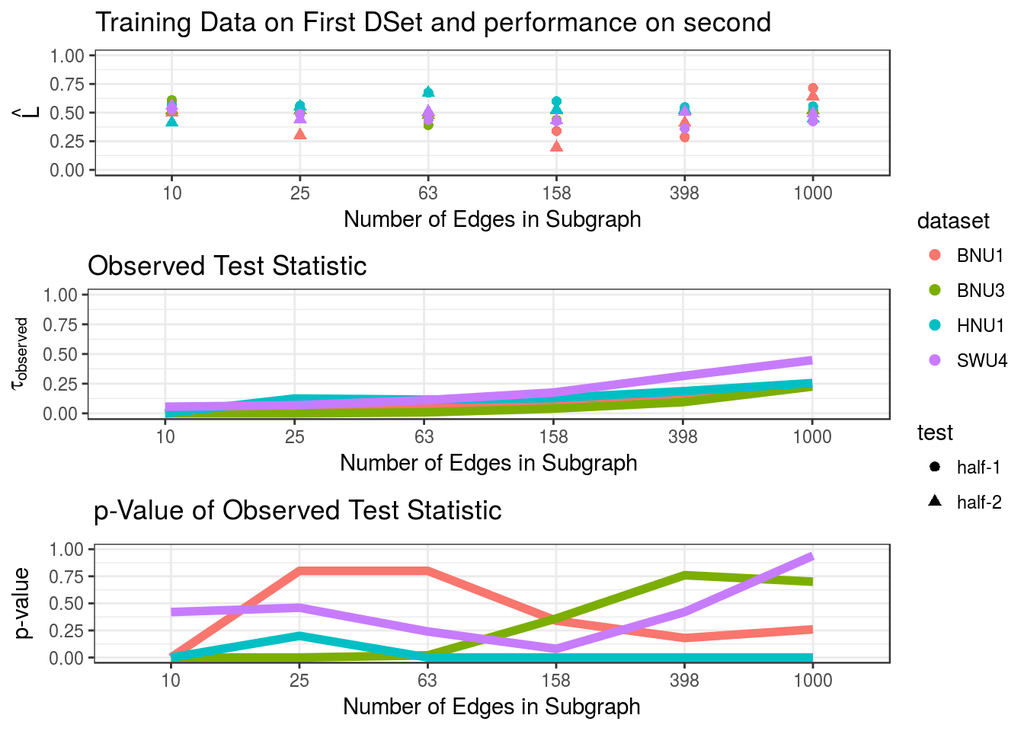

```r
result <- readRDS('/data/paper/subgraphing_results/case2dwi.rds')
data <- prepare_case2(result)
plot_case2(data)
```

### fMRI

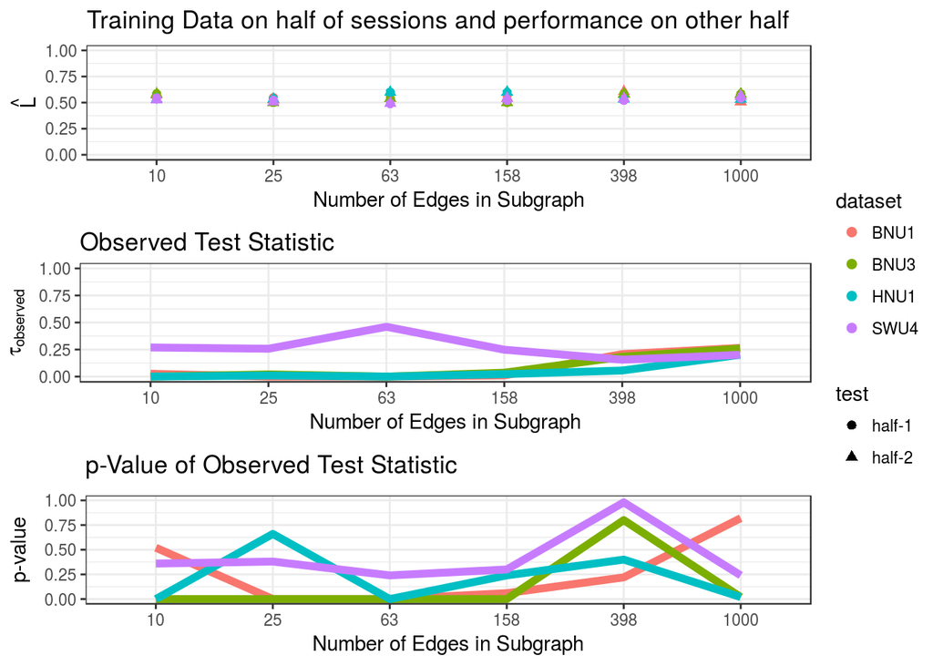

```r
result <- readRDS('/data/paper/subgraphing_results/case2fmri.rds')
data <- prepare_case2(result)
plot_case1(data)
```

# Case 3: Same Site

- Take 2 out-of-sample studies at same site. Sets are study 1 at site $\alpha$, and study 2 at site $\alpha$.
- Is there a batch effect between studies with site held fixed?

## Procedure

- Take first dataset as set 1, other as set 2.
1. Train model on first dataset, and test on second half to obtain $\hat{L}_1$, and train model on second half, and test on second group of subjects to obtain $\hat{L}_2$.
2. Train model on both sets at once, and obtain $\tau_{observed}$
3. permute the set labels of the combined set $nperm$ times (maintaining sex of each graph) to obtain the distribution of $\tau_{null}$, reporting $\hat{p}$, the estimator of $\mathbb{E}\left[\frac{\tau_{null} < \tau_{observed}}{nperm}\right]$

### DWI

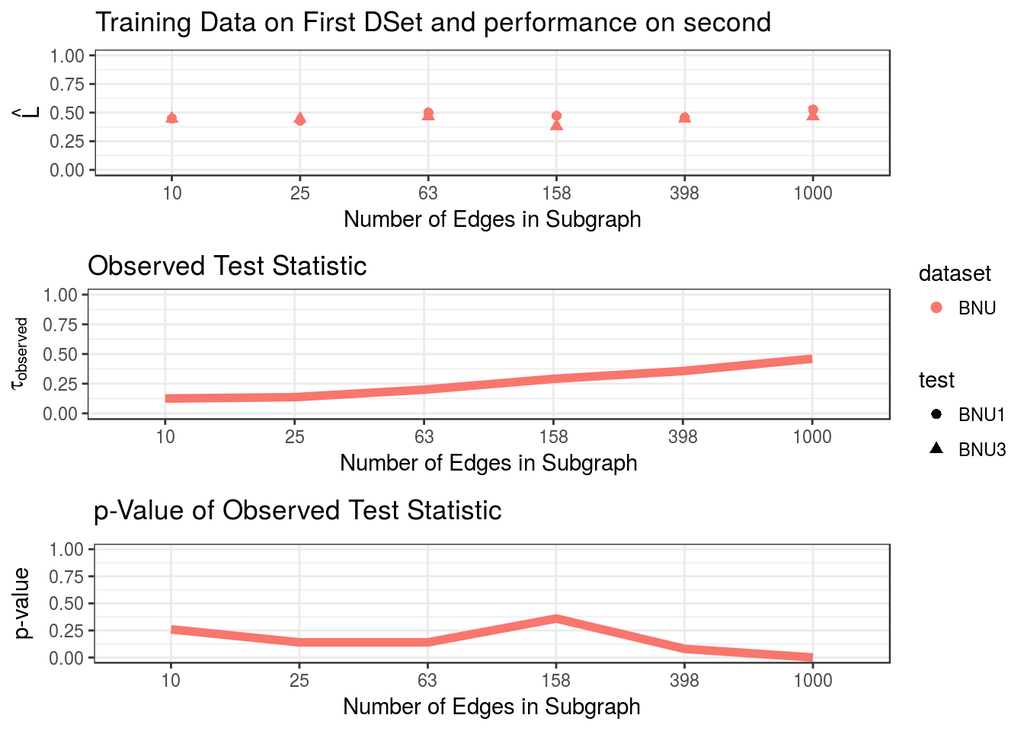

```r
result <- readRDS('/data/paper/subgraphing_results/case3dwi.rds')
data <- prepare_case3(result)
plot_case3(data)
```

### fMRI

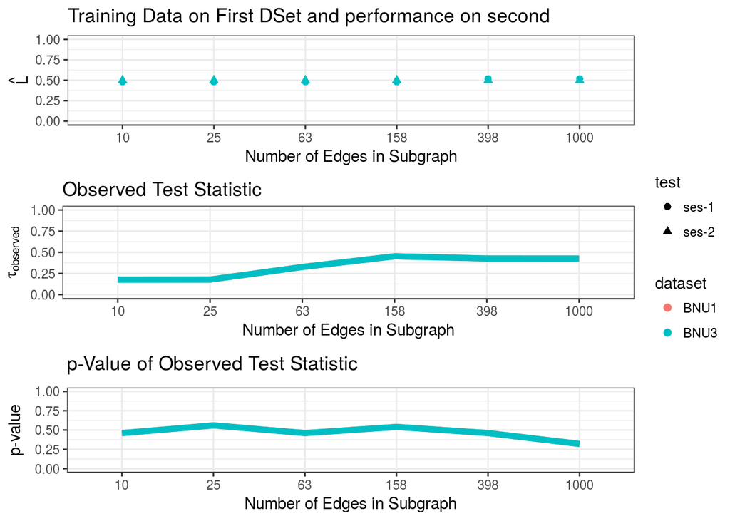

```r
result <- readRDS('/data/paper/subgraphing_results/case3fmri.rds')
data <- prepare_case1(result)
plot_case3(data)
```

# Case 4

Take 2 studies with same demographics. Sets are study 1 at site $\alpha$ with demographics $d_1$, and study 2 at site $\beta$ with demographics $d_1$.  
Is there a batch effect between sites with demographic held fixed?

## Procedure

- Take first dataset as set 1, other as set 2.
1. Train model on first dataset, and test on second half to obtain $\hat{L}_1$, and train model on second half, and test on second group of subjects to obtain $\hat{L}_2$.
2. Train model on both sets at once, and obtain $\tau_{observed}$
3. permute the set labels of the combined set $nperm$ times (maintaining sex of each graph) to obtain the distribution of $\tau_{null}$, reporting $\hat{p}$, the estimator of $\mathbb{E}\left[\frac{\tau_{null} < \tau_{observed}}{nperm}\right]$

### DWI

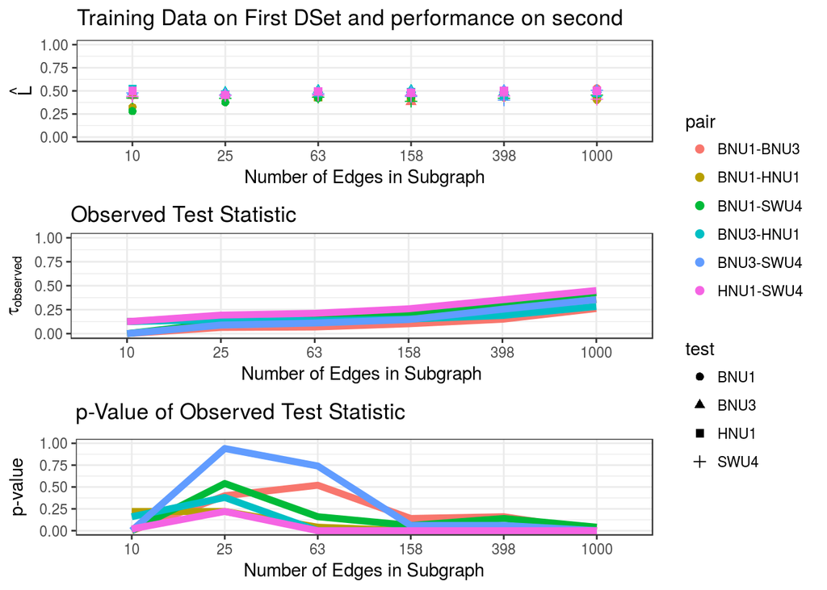

```r
result <- readRDS('/data/paper/subgraphing_results/case4dwi.rds')
data <- prepare_case45(result)
plot_case45(data)
```

### fMRI

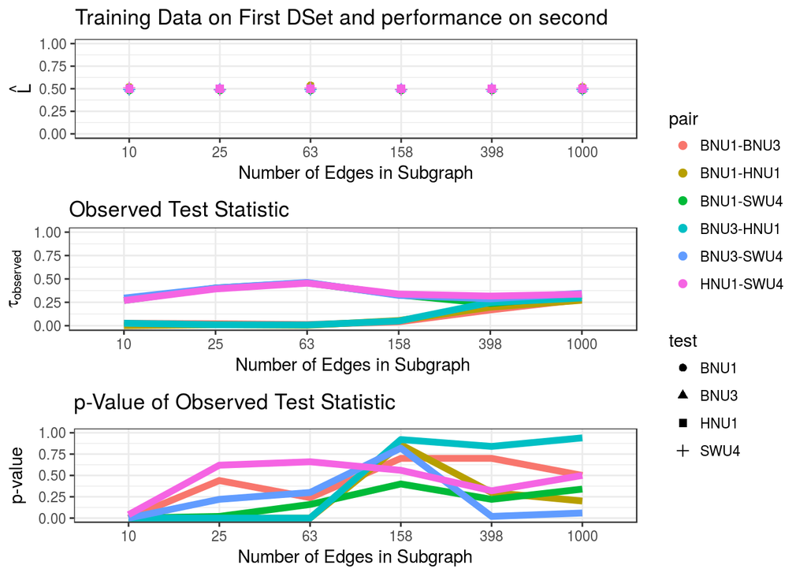

```r
result <- readRDS('/data/paper/subgraphing_results/case4fmri.rds')
data <- prepare_case45(result)
plot_case45(data)
```

# Case 5

Take 2 studies with different demographics. Sets are study 1 at site $\alpha$ with demographics $d_1$, and study 2 at site $\beta$ with demographics $d_2$.  
Is there a batch effect between sites with demographic held fixed?

## Procedure

- Take first dataset as set 1, other as set 2.
1. Train model on first dataset, and test on second half to obtain $\hat{L}_1$, and train model on second half, and test on second group of subjects to obtain $\hat{L}_2$.
2. Train model on both sets at once, and obtain $\tau_{observed}$
3. permute the set labels of the combined set $nperm$ times (maintaining sex of each graph) to obtain the distribution of $\tau_{null}$, reporting $\hat{p}$, the estimator of $\mathbb{E}\left[\frac{\tau_{null} < \tau_{observed}}{nperm}\right]$

### DWI

```r
result <- readRDS('/data/paper/subgraphing_results/case5dwi.rds')
data <- prepare_case5(result)
plot_case5(data)
```

[output not shown]

### fMRI

```r
result <- readRDS('/data/paper/subgraphing_results/case1fmri.rds')
data <- prepare_case5(result)
plot_case5(data)
```

[output not shown]